# Exam 3 Code

Trelan Hakeem-Barron

3/27/2020

```r
library(TSA)
library(forecast)
library(astsa)
```

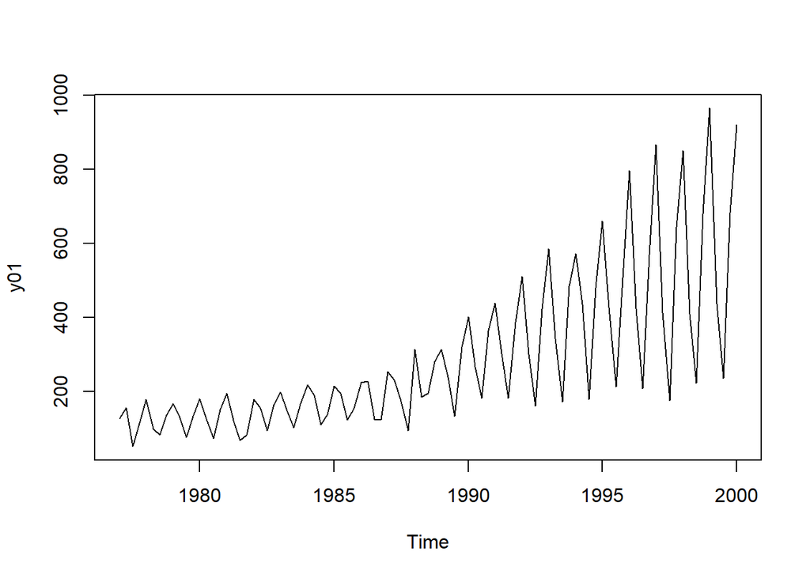

```r
load(url("http://goo.gl/Zqn3Ea"))
plot(y01)
```

# 1)

```r
mymodel = tslm(y01 ~ season)
s = summary(mymodel)
s
```

```
##
## Call:
## tslm(formula = y01 ~ season)
##
## Residuals:
##     Min      1Q  Median      3Q     Max
## -303.71 -137.45  -22.14   84.48  534.86
##
## Coefficients:
##             Estimate Std. Error t value Pr(>|t|)
## (Intercept)   430.65      38.01  11.330  < 2e-16 ***
## season2      -171.46      54.34  -3.156  0.00219 **
## season3      -285.21      54.34  -5.249 1.03e-06 ***
## season4      -113.93      54.34  -2.097  0.03886 *
## ---
## Signif. codes:  0 '***' 0.001 '**' 0.01 '*' 0.05 '.' 0.1 ' ' 1
##
## Residual standard error: 186.2 on 89 degrees of freedom
## Multiple R-squared:  0.2436, Adjusted R-squared:  0.2181
## F-statistic: 9.552 on 3 and 89 DF,  p-value: 1.56e-05
```

A model has the form:
$$y(t)=430.65-171.46*season2*x_{(2,t)}-285.21*season3*x_{(3,t)}-113.93*season4*x_{(4,t)}$$
Where season2,season3,season4 are dummy variables (indicators of event) of quarterly 2,3, and 4 respectively.

# 2)

Plot of residuals:

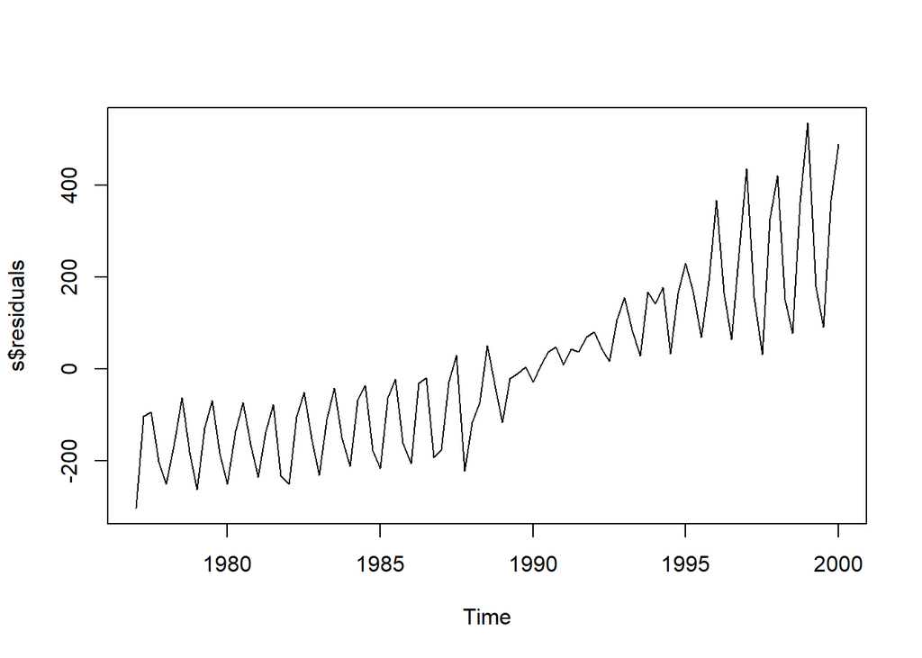

```r
plot(s$residuals)
```

The residuals are non-uniform with respect to zero, therefore only seasonality is not enough to forecast the time series.

ACF:

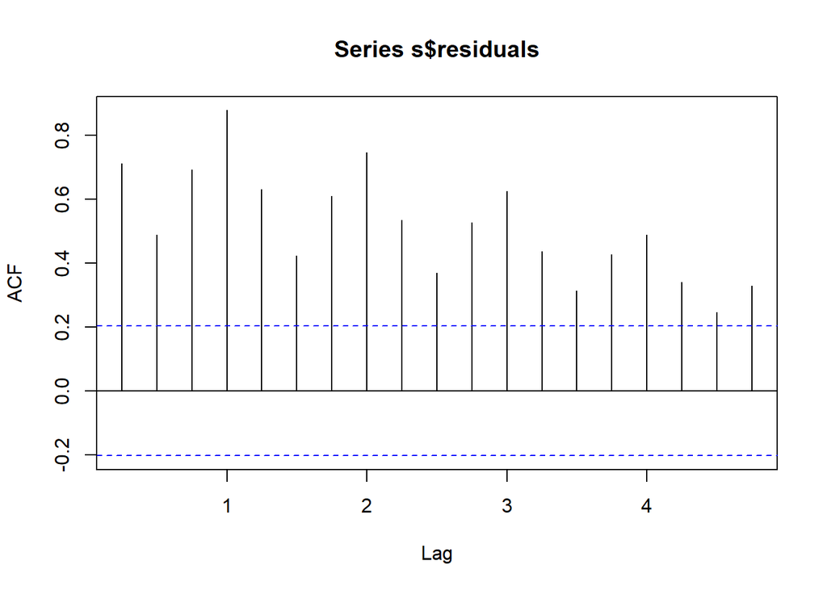

```r
acf(s$residuals)
```

The residuals are correlated.

We can conclude that we got a rather bad model. This is also seen from the forecast graph below:

# 3)

```r
forecast(mymodel, h = 8)
```

```
##         Point Forecast      Lo 80    Hi 80      Lo 95    Hi 95
## 2000 Q2       259.1908   13.59674 504.7849 -118.76327 637.1449
## 2000 Q3       145.4417 -100.15239 391.0358 -232.51240 523.3958
## 2000 Q4       316.7215   71.12745 562.3156  -61.23256 694.6756
## 2001 Q1       430.6478  185.26695 676.0286   53.02189 808.2736
## 2001 Q2       259.1908   13.59674 504.7849 -118.76327 637.1449
## 2001 Q3       145.4417 -100.15239 391.0358 -232.51240 523.3958
## 2001 Q4       316.7215   71.12745 562.3156  -61.23256 694.6756
## 2002 Q1       430.6478  185.26695 676.0286   53.02189 808.2736
```

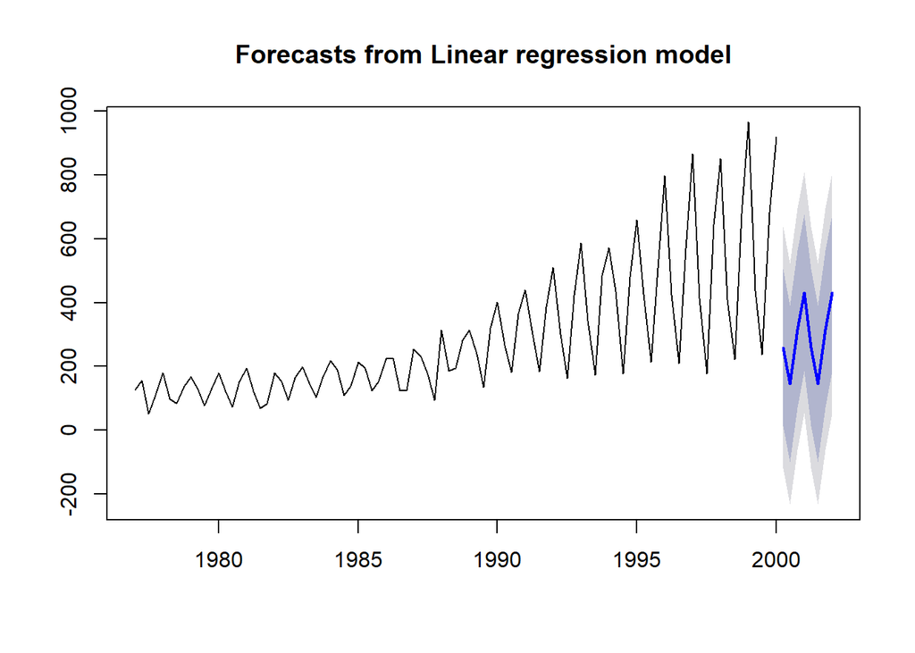

```r
plot(forecast(mymodel, h = 8))
```

# 1)

```r
mymodel = arima(y01, order = c(1,1,1), seasonal = list(order = c(1,1,0), period = 4))
mymodel
```

[output not shown]

# 2)

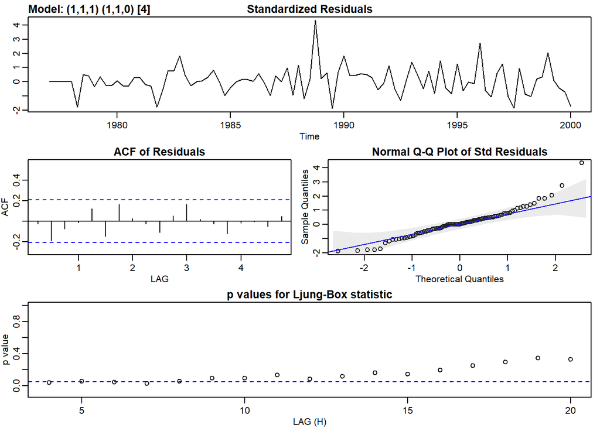

```
## $fit
##
## Call:
## stats::arima(x = xdata, order = c(p, d, q), seasonal = list(order = c(P, D,
##     Q), period = S), include.mean = !no.constant, transform.pars = trans, fixed = fixed,
##     optim.control = list(trace = trc, REPORT = 1, reltol = tol))
##
## Coefficients:
##           ar1      ma1     sar1
##       -0.1505  -0.9312  -0.0954
## s.e.   0.1112   0.0378   0.1121
##
## sigma^2 estimated as 1675:  log likelihood = -452.75,  aic = 913.49
##
## $degrees_of_freedom
## [1] 85
##
## $ttable
##      Estimate     SE  t.value p.value
## ar1   -0.1505 0.1112  -1.3530  0.1796
## ma1   -0.9312 0.0378 -24.6289  0.0000
## sar1  -0.0954 0.1121  -0.8512  0.3970
##
## $AIC
## [1] 10.03839
##
## $AICc
## [1] 10.04143
##
## $BIC
## [1] 10.14729
```

```r
sarima(y01, 1,1,1,1,1,0,4)
```

But on the plot of p-values of the test at points 4, 6, 7, we see the dependence in this time series.

# 3)

The model of part B is better than the model of part A, but it can be improved by choosing the right parameters. One solution to this problem is to use the auto.arima() function

```r
auto.arima(y01,max.p = 10,
           max.q = 10,
           max.P = 10,
           max.Q = 10,
           max.order = 10,
           max.d = 10,
           max.D = 1,
           start.p = 0,
           start.q = 0,
           start.P = 0,
           start.Q = 0)
```

```
## Series: y01
## ARIMA(1,1,2)(0,1,0)[4]
##
## Coefficients:
##          ar1      ma1     ma2
##       0.4538  -1.6307  0.6648
## s.e.  0.2911   0.2651  0.2548
##
## sigma^2 estimated as 1671:  log likelihood=-451.24
## AIC=910.48   AICc=910.96   BIC=920.39
```

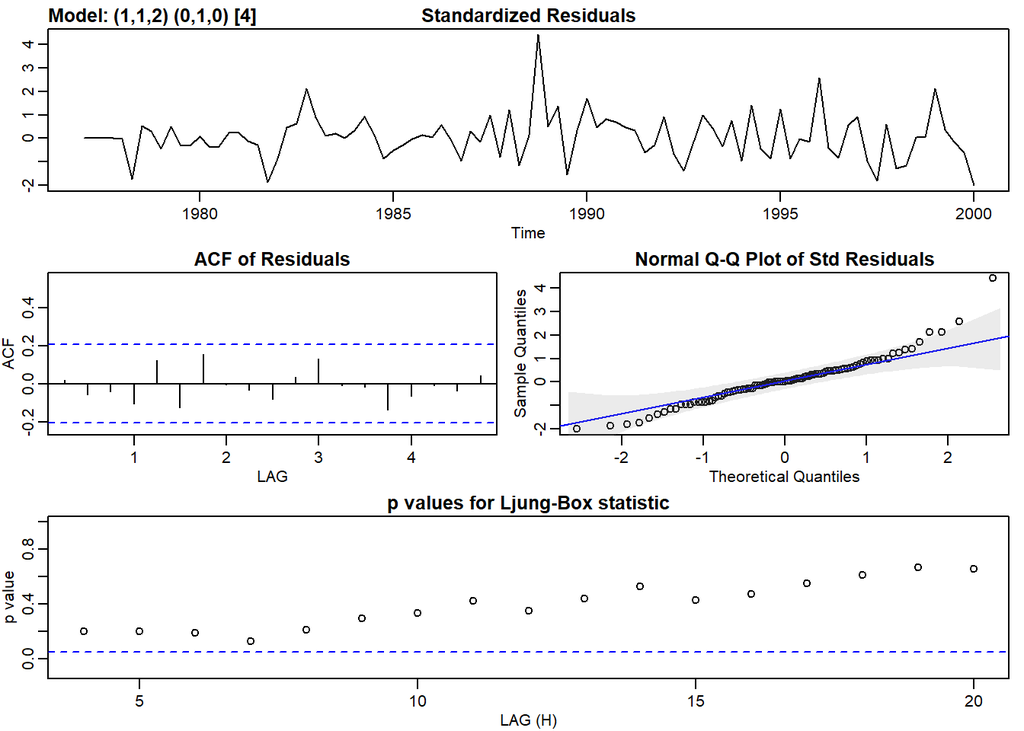

```r
mymodel1 = sarima(y01, 1,1,2,0,1,0,4)
```

```r
mymodel1
```

```
## $fit
##
## Call:
## stats::arima(x = xdata, order = c(p, d, q), seasonal = list(order = c(P, D,
##     Q), period = S), include.mean = !no.constant, transform.pars = trans, fixed = fixed,
##     optim.control = list(trace = trc, REPORT = 1, reltol = tol))
##
## Coefficients:
##          ar1      ma1     ma2
##       0.4538  -1.6307  0.6648
## s.e.  0.2911   0.2651  0.2548
##
## sigma^2 estimated as 1614:  log likelihood = -451.24,  aic = 910.48
##
## $degrees_of_freedom
## [1] 85
##
## $ttable
##     Estimate     SE t.value p.value
## ar1   0.4538 0.2911  1.5591  0.1227
## ma1  -1.6307 0.2651 -6.1525  0.0000
## ma2   0.6648 0.2548  2.6097  0.0107
##
## $AIC
## [1] 10.00529
##
## $AICc
## [1] 10.00832
##
## $BIC
## [1] 10.11418
```

A model has the form:
$$(1-0.4538L)(1-L)(1-L^4 )y(t)=\varepsilon_t-1.6307\varepsilon_{(t-1)}+0.6648\varepsilon_{(t-2)}$$
where $L$ is Lag-operator.

Forecast:

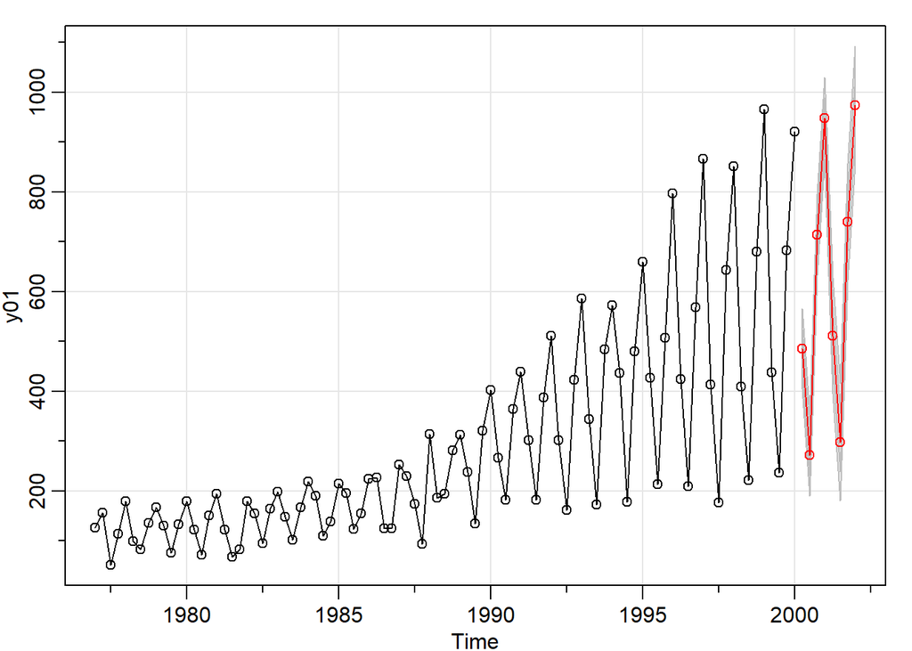

```
## $pred
##          Qtr1     Qtr2     Qtr3     Qtr4
## 2000          485.1280 271.8816 713.4387
## 2001 948.1090 511.9485 298.2147 739.5507
## 2002 974.1206
##
## $se
##          Qtr1     Qtr2     Qtr3     Qtr4
## 2000          40.17085 40.79503 40.83724
## 2001 40.84064 58.42494 58.63932 58.64117
## 2002 58.71532
```

```r
sarima.for(y01, 8,  1,1,2,0,1,0,4)
```

# 4)

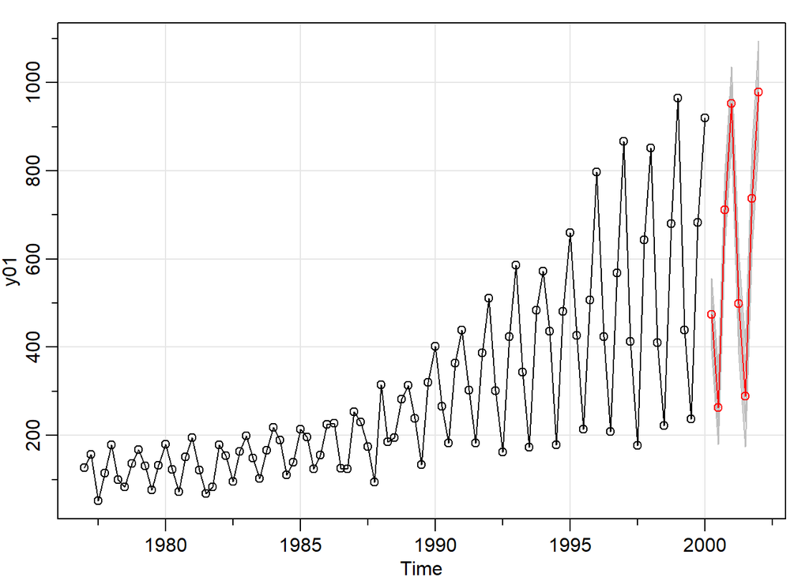

```
## $pred
##          Qtr1     Qtr2     Qtr3     Qtr4
## 2000          473.6559 262.3243 711.7509
## 2001 953.2184 498.9857 288.5629 737.7371
## 2002 978.7816
##
## $se
##          Qtr1     Qtr2     Qtr3     Qtr4
## 2000          40.92877 41.06489 41.19891
## 2001 41.26407 57.11634 57.11924 57.37894
## 2002 57.55873
```

```r
sarima.for(y01, 8, 1,1,1,1,1,0,4)
```

# Part C

Of course, the model of part B is much better than the model of part A. This can be seen both in the forecast graph and in the diagnostic graphs of residuals.